# Data Nerd Challenge

Let’s define a function that we want to graph. It will be a simple square value of X:

```
y = x²
```

In programming languages, this expression of x squared in actual code looks more like:

```
y = x^2
```

A function is expressed using the notation `f(x)`. This is the same thing as `y` in the previous expression and is pronounced “F of X”. So the same expression above now looks like this:

```
f(x) = x^2
```

So, again, `y` and `f(x)` mean the same thing, but `f(x)` is the name of the function.

The way you code a function in R to perform the x squared function looks like this:

```r
f <- function(x) { x^2 }
```

Notice the color of the text above looks different. That’s because it’s actual code written in the programming language known as ‘R’.

Now we can create a function table by defining a domain of values for the function. We will choose `x` values from -10 to 10 in increments of 0.5. It looks like this:

```r
x <- c(-10, -9.5, -9, -8.5, -8, -7.5, -7, -6.5, -6, -5.5, -5, -4.5, -4, -3.5, -3, -2.5, -2, -1.5, -1, -0.5,
       0, 0.5, 1, 1.5, 2, 2.5, 3, 3.5, 4, 4.5, 5, 5.5, 6, 6.5, 7, 7.5, 8, 8.5, 9, 9.5, 10)
```

The notation `c(...)` means “a collection of numbers”. In R and many other programming languages we call this an “array”.

So now `x` is an array of numbers we are using for the domain and looks like this:

```r
x
```

```
##  [1] -10.0  -9.5  -9.0  -8.5  -8.0  -7.5  -7.0  -6.5  -6.0  -5.5  -5.0  -4.5
## [13]  -4.0  -3.5  -3.0  -2.5  -2.0  -1.5  -1.0  -0.5   0.0   0.5   1.0   1.5
## [25]   2.0   2.5   3.0   3.5   4.0   4.5   5.0   5.5   6.0   6.5   7.0   7.5
## [37]   8.0   8.5   9.0   9.5  10.0
```

Here is the code to calculate the `y` values to put in the table:

```r
y <- f(x)
```

Here is the table:

| x | y |
| --- | --- |
| -10.0 | 100.00 |
| -9.5 | 90.25 |
| -9.0 | 81.00 |
| -8.5 | 72.25 |
| -8.0 | 64.00 |
| -7.5 | 56.25 |
| -7.0 | 49.00 |
| -6.5 | 42.25 |
| -6.0 | 36.00 |
| -5.5 | 30.25 |
| -5.0 | 25.00 |
| -4.5 | 20.25 |
| -4.0 | 16.00 |
| -3.5 | 12.25 |
| -3.0 | 9.00 |
| -2.5 | 6.25 |
| -2.0 | 4.00 |
| -1.5 | 2.25 |
| -1.0 | 1.00 |
| -0.5 | 0.25 |
| 0.0 | 0.00 |
| 0.5 | 0.25 |
| 1.0 | 1.00 |
| 1.5 | 2.25 |
| 2.0 | 4.00 |
| 2.5 | 6.25 |
| 3.0 | 9.00 |
| 3.5 | 12.25 |
| 4.0 | 16.00 |
| 4.5 | 20.25 |
| 5.0 | 25.00 |
| 5.5 | 30.25 |
| 6.0 | 36.00 |
| 6.5 | 42.25 |
| 7.0 | 49.00 |
| 7.5 | 56.25 |
| 8.0 | 64.00 |
| 8.5 | 72.25 |
| 9.0 | 81.00 |
| 9.5 | 90.25 |
| 10.0 | 100.00 |

Now let’s plot these values!

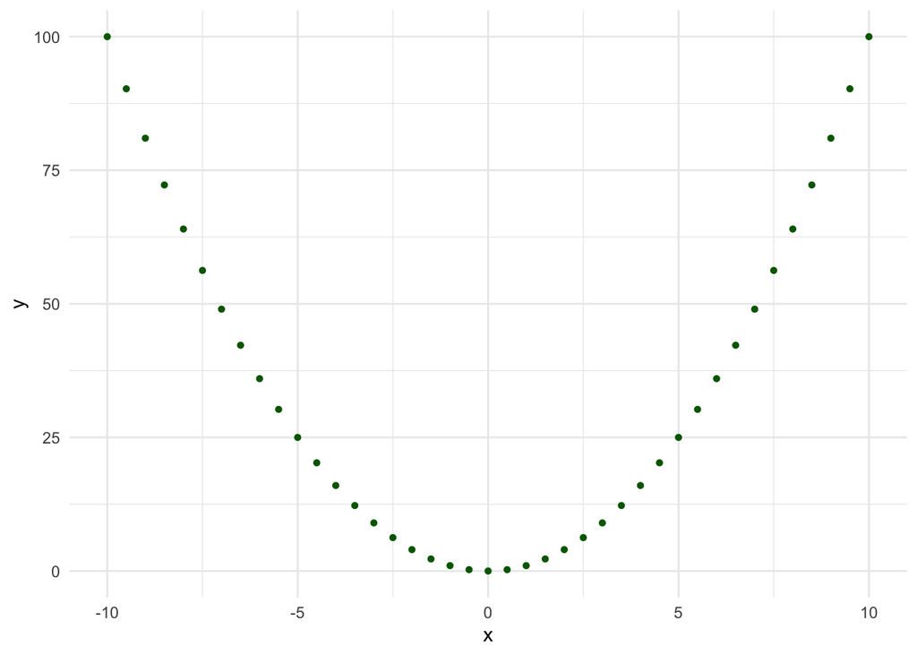

What if we wanted to see the difference between `y` values, instead of the actual `y` values themselves? In other words, let’s see if we can take each value of the function `f(x)=x²` and plot the difference between the adjacent values themselves. So for the i’th value of `x`, we take the difference between `f(xᵢ₊₁)` and `f(xᵢ₋₁)`.

| x | y | difference |  |
| --- | --- | --- | --- |
| -2.5 | 6.25 |  |  |
| -2.0 | 4.00 | 2.25 - 6.25 = | -4 |
| -1.5 | 2.25 | 1 - 4 = | -3 |
| -1.0 | 1.00 | 0.25 - 2.25 = | -2 |
| -0.5 | 0.25 | 0 - 1 = | -1 |
| 0.0 | 0.00 | 0.25 - 0.25 = | 0 |
| 0.5 | 0.25 | 1 - 0 = | 1 |
| 1.0 | 1.00 | 2.25 - 0.25 = | 2 |
| 1.5 | 2.25 | 4 - 1 = | 3 |
| 2.0 | 4.00 | 6.25 - 2.25 = | 4 |
| 2.5 | 6.25 |  |  |

What would the graph look like if we plotted both the `x²` value and the difference between the two `y` values next to each other?

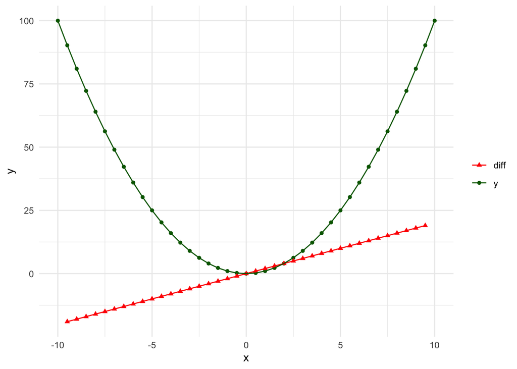

Another way to look at this is that for any `x` value in the plot above, the slope at the round dot on the green line is given by the `y` value at the red triangle.

For example, if you were to draw a straight line parallel to the green line where `x` = 5, the slope of that line would be 10, which is given by the `y` value on the red line at `(5, 10)`. See the black dashed line in the graph below. The formula for this line is `y = 10x - 25`. You can see we got the 10 from the value on the red line at `x` = 5.

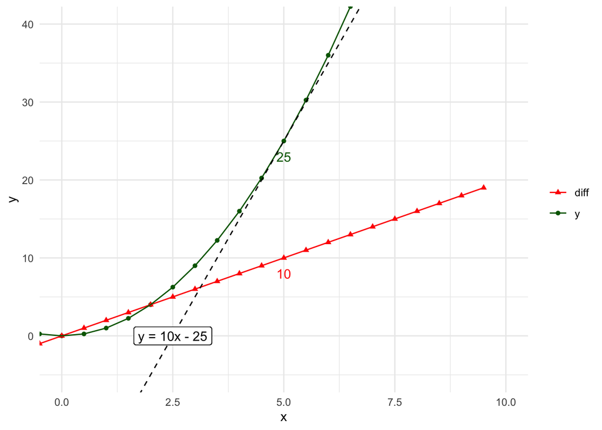

Look at the plot of the “diff” above, in red. This is a plot of what is know as the derivative function. Specifically it’s the “first derivative of the function `y=x²`”.

You can see it’s a straight line. We call this a “linear function”. So the first derivative of `y=x²` is a linear function.

# Special Challenge

Okay so here are some challenges to test your understanding. If you can get these right I will award you one chore pass which you can use for emptying trash, emptying the dishwasher, or taking the trash bins to or from the curb.

### Problem #1

Can you determine the slope and y intercept of derivative (red) line? (Hint: the slope is **not** 1!)

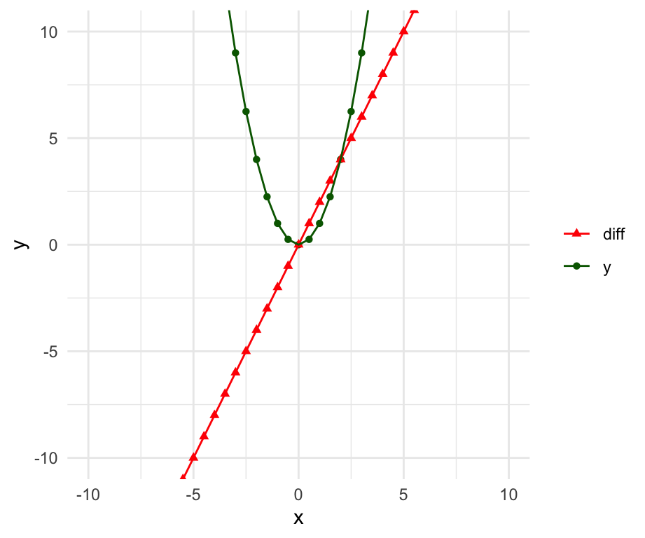

### Problem #2

Can you write the function of the first derivative in slope intercept form?

#### Answer:

### Problem #3

Now that you know the first derivative of `y=x²` can you guess the first derivative of the function `y=x²+1`?

#### Answer:

### Super Bonus Challenge

If you can get this without cheating (using the internet) then I will give you one more chore pass.

Can you determine the first derivative of the function `y=-2x²`?

#### Answer: